# Survival Analysis

# 1. What ist Survival Analysis?

Survival analysis encompasses a variety of techniques to predict if or when a subject under observation will experience an event (failure, death, etc.) and to find out the hazard of an event going to happen or the probability that a subject will survive.

**Typical fields of application are:**  
Medical studies  
*Credit risk modeling*  
Marketing  
*Failure prediction and monitoring of technical devices

**Predictors are domain spedific:**  
Health data: blood sugar levels ,heart rate, eating habits  
*Customer data: income, job, family situation*  
Monitoring data: machine status, uptimes, error counts

Parametric techniques consider predictors, non parametric techniques only look at the event/no event ratio of all subjects.

**Three Main Groups**

```r
print(sagroups,type ="html")
```

| Non-parametric: | Semi-parametric: | Parametric: |
| --- | --- | --- |
| Kaplan Meyer | Cox Proportional Hazard | Accelerated Failure Time |
| NA | Gradient Boosting with Cox | NA |
| NA | Gradient Boosting Machine CI | NA |

## Dataset overview

```r
print(ds,type ="html")
```

| Dataset: | Nr. Observations | Nr. Features | Time Varying Covariates | Censored | Type |
| --- | --- | --- | --- | --- | --- |
| HDD SMART States | 105855 | 12 | yes | right | Technical Monitoring |
| pbc | 418 | 20 | no | right | Medical |
| NA | NA | NA | NA | NA | NA |

### Datasets en Detail

#### PDC Set

#### Number of Items:

```r
print(NROW(pbc))
```

```
[1] 418
```

#### Number of Items to fail:

```r
print(NROW(pbc[pbc$status ==2,]))
```

```
[1] 161
```

#### Structure:

```r
print(head(pbc,10))
```

|  | id | time | status | trt | age | sex | ascites | hepato | spiders | edema | bili | chol | albumin | copper | alk.phos | ast | trig | platelet | protime | stage |
| --- | --- | --- | --- | --- | --- | --- | --- | --- | --- | --- | --- | --- | --- | --- | --- | --- | --- | --- | --- | --- |
| 1 | 1 | 400 | 2 | 1 | 58.76523 | f | 1 | 1 | 1 | 1.0 | 14.5 | 261 | 2.60 | 156 | 1718.0 | 137.95 | 172 | 190 | 12.2 | 4 |
| 2 | 2 | 4500 | 0 | 1 | 56.44627 | f | 0 | 1 | 1 | 0.0 | 1.1 | 302 | 4.14 | 54 | 7394.8 | 113.52 | 88 | 221 | 10.6 | 3 |
| 3 | 3 | 1012 | 2 | 1 | 70.07255 | m | 0 | 0 | 0 | 0.5 | 1.4 | 176 | 3.48 | 210 | 516.0 | 96.10 | 55 | 151 | 12.0 | 4 |
| 4 | 4 | 1925 | 2 | 1 | 54.74059 | f | 0 | 1 | 1 | 0.5 | 1.8 | 244 | 2.54 | 64 | 6121.8 | 60.63 | 92 | 183 | 10.3 | 4 |
| 5 | 5 | 1504 | 1 | 2 | 38.10541 | f | 0 | 1 | 1 | 0.0 | 3.4 | 279 | 3.53 | 143 | 671.0 | 113.15 | 72 | 136 | 10.9 | 3 |
| 6 | 6 | 2503 | 2 | 2 | 66.25873 | f | 0 | 1 | 0 | 0.0 | 0.8 | 248 | 3.98 | 50 | 944.0 | 93.00 | 63 | NA | 11.0 | 3 |
| 7 | 7 | 1832 | 0 | 2 | 55.53457 | f | 0 | 1 | 0 | 0.0 | 1.0 | 322 | 4.09 | 52 | 824.0 | 60.45 | 213 | 204 | 9.7 | 3 |
| 8 | 8 | 2466 | 2 | 2 | 53.05681 | f | 0 | 0 | 0 | 0.0 | 0.3 | 280 | 4.00 | 52 | 4651.2 | 28.38 | 189 | 373 | 11.0 | 3 |
| 9 | 9 | 2400 | 2 | 1 | 42.50787 | f | 0 | 0 | 1 | 0.0 | 3.2 | 562 | 3.08 | 79 | 2276.0 | 144.15 | 88 | 251 | 11.0 | 2 |
| 10 | 10 | 51 | 2 | 2 | 70.55989 | f | 1 | 0 | 1 | 1.0 | 12.6 | 200 | 2.74 | 140 | 918.0 | 147.25 | 143 | 302 | 11.5 | 4 |

#### HDD Set

Contains hard disc failure predictors (SMART States)

##### Number of Items:

```r
print(NROW(unique(c$serial_number)))
```

```
[1] 22123
```

##### Number of Items to fail:

```r
print(NROW(unique(c[c$failure ==1,]$serial_number)))
```

```
[1] 263
```

##### Structure:

```r
print(c[c$serial_number %in% c("MJ0351YNG9Z0XA","W300K6X5"), ])
```

|  | date | serial_number | model | smart_9_normalized | smart_9_raw | smart_5_normalized | smart_187_normalized | smart_188_normalized | smart_197_normalized | smart_198_normalized | failure |
| --- | --- | --- | --- | --- | --- | --- | --- | --- | --- | --- | --- |
| 1 | 1 | MJ0351YNG9Z0XA | Hitachi HDS5C3030ALA630 | 97 | 27929 | 100 | 100 | 100 | 100 | 100 | 0 |
| 17266 | 1 | W300K6X5 | ST4000DM000 | 81 | 16828 | 100 | 100 | 100 | 100 | 100 | 0 |
| 5087760 | 90 | MJ0351YNG9Z0XA | Hitachi HDS5C3030ALA630 | 96 | 30064 | 100 | 100 | 100 | 100 | 100 | 0 |
| 5104817 | 90 | W300K6X5 | ST4000DM000 | 79 | 18962 | 100 | 100 | 100 | 100 | 100 | 0 |
| 10130610 | 180 | MJ0351YNG9Z0XA | Hitachi HDS5C3030ALA630 | 96 | 32224 | 100 | 100 | 100 | 100 | 100 | 0 |
| 10145650 | 180 | W300K6X5 | ST4000DM000 | 76 | 21122 | 100 | 100 | 100 | 100 | 100 | 0 |
| 14960631 | 270 | MJ0351YNG9Z0XA | Hitachi HDS5C3030ALA630 | 96 | 34384 | 100 | 100 | 100 | 100 | 100 | 0 |
| 14976171 | 270 | W300K6X5 | ST4000DM000 | 74 | 23283 | 100 | 100 | 100 | 100 | 100 | 0 |
| 19914547 | 366 | MJ0351YNG9Z0XA | Hitachi HDS5C3030ALA630 | 95 | 36689 | 100 | 100 | 100 | 100 | 100 | 0 |
| 18953060 | 347 | W300K6X5 | ST4000DM000 | 72 | 25131 | 100 | 100 | 100 | 100 | 100 | 1 |

# 2. Survival Analysis Techniques

## 2.1 Kaplan Meyer

### 2.1.1. Preparations

#### Create a survival element by Surv function

#### Load the package data

### 2.1.2. Application of KM

#### Produce and plot Kaplan-Meier estimator by survfit function

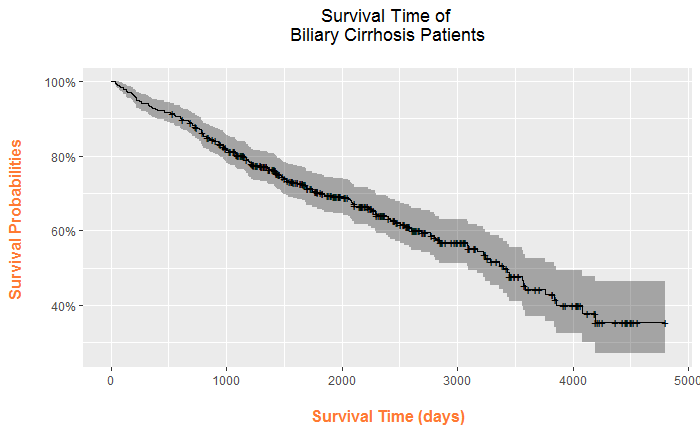

```r
model_fit_simple <- survfit(Surv(pbc$time, pbc$status == 2) ~ 1)
autoplot(model_fit_simple) +
    labs(x = "\n Survival Time (days) ", y = "Survival Probabilities \n",
    title = "Survival Time of \n Biliary Cirrhosis Patients \n") +
    theme(plot.title = element_text(hjust=0.5),
    axis.title.x = element_text(face = "bold", color = "#FF7A33", size = 12),
    axis.title.y = element_text(face = "bold", color = "#FF7A33", size = 12),
    legend.title = element_text(face = "bold", size = 10))
```

#### Show Kaplan-Meier estimates

```r
print(summary(model_fit_simple))
```

```
Call: survfit(formula = Surv(pbc$time, pbc$status == 2) ~ 1)

 time n.risk n.event survival std.err lower 95% CI upper 95% CI
   41    418       2    0.995 0.00338        0.989        1.000
   43    416       1    0.993 0.00413        0.985        1.000
   51    415       1    0.990 0.00476        0.981        1.000
   71    414       1    0.988 0.00532        0.978        0.999
   77    413       1    0.986 0.00582        0.974        0.997
   94    412       1    0.983 0.00628        0.971        0.996
  110    411       1    0.981 0.00670        0.968        0.994
  111    410       1    0.978 0.00710        0.965        0.992
  130    409       1    0.976 0.00747        0.962        0.991
  131    408       1    0.974 0.00783        0.958        0.989
  140    407       1    0.971 0.00817        0.955        0.987
  179    406       1    0.969 0.00849        0.952        0.986
```

[output cut: 131 more lines]

#### Plot differences on the different treatments

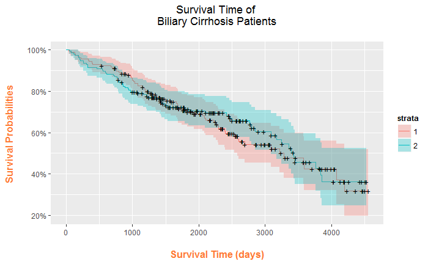

```r
model_fit_trt <- survfit(Surv(pbc$time, pbc$status == 2) ~ pbc$trt)
autoplot(model_fit_trt) +
    labs(x = "\n Survival Time (days) ", y = "Survival Probabilities \n",
    title = "Survival Time of \n Biliary Cirrhosis Patients \n") +
    theme(plot.title = element_text(hjust=0.5),
    axis.title.x = element_text(face = "bold", color = "#FF7A33", size = 12),
    axis.title.y = element_text(face = "bold", color = "#FF7A33", size = 12),
    legend.title = element_text(face = "bold", size = 10))
```

#### Show Kaplan-Meier estimates

```r
print(summary(model_fit_trt))
```

```
Call: survfit(formula = Surv(pbc$time, pbc$status == 2) ~ pbc$trt)

106 observations deleted due to missingness
                pbc$trt=1
 time n.risk n.event survival std.err lower 95% CI upper 95% CI
   41    158       1    0.994 0.00631        0.981        1.000
   71    157       1    0.987 0.00889        0.970        1.000
  131    156       1    0.981 0.01086        0.960        1.000
  140    155       1    0.975 0.01250        0.950        0.999
  179    154       1    0.968 0.01393        0.941        0.996
  198    153       1    0.962 0.01521        0.933        0.992
  223    152       1    0.956 0.01637        0.924        0.988
  334    151       1    0.949 0.01744        0.916        0.984
  348    150       1    0.943 0.01844        0.908        0.980
  388    149       1    0.937 0.01937        0.900        0.975
```

[output cut: 115 more lines]

#### Performing the Mantel-Haenzel test

Performing the Mantel-Haenzel test on conditional indepencence by function survdiff. Efficient in comparing groups that differ by categorical variables, but not continuous ones. The test statistic value is less than the critical value (using chi-square table) for degree of freedom equal to one. Hence, we can say that there is no significant difference between the two groups regarding the survival. We can follow that the actual treatment of these patients gave little impact on the survival chances.

```r
survdiff(Surv(pbc$time, pbc$status==2)~pbc$trt)
```

```
Call:
survdiff(formula = Surv(pbc$time, pbc$status == 2) ~ pbc$trt)

n=312, 106 observations deleted due to missingness.

            N Observed Expected (O-E)^2/E (O-E)^2/V
pbc$trt=1 158       65     63.2    0.0502     0.102
pbc$trt=2 154       60     61.8    0.0513     0.102

 Chisq= 0.1  on 1 degrees of freedom, p= 0.75
```

#### Plot differences on males and females and test log-rank test

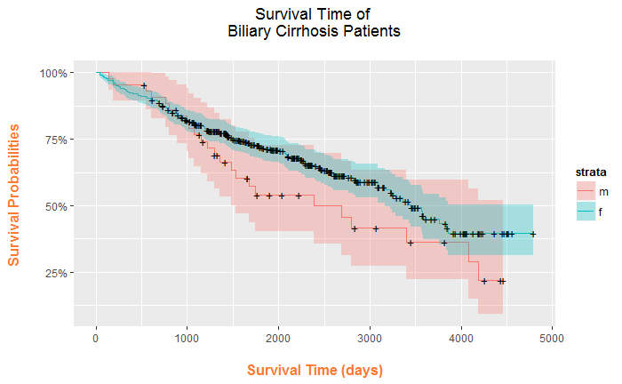

```r
model_fit_sex <- survfit(Surv(pbc$time, pbc$status == 2) ~ pbc$sex)
autoplot(model_fit_sex) +
    labs(x = "\n Survival Time (days) ", y = "Survival Probabilities \n",
    title = "Survival Time of \n Biliary Cirrhosis Patients \n") +
    theme(plot.title = element_text(hjust=0.5),
    axis.title.x = element_text(face = "bold", color = "#FF7A33", size = 12),
    axis.title.y = element_text(face = "bold", color = "#FF7A33", size = 12),
    legend.title = element_text(face = "bold", size = 10))
```

```r
survdiff(Surv(pbc$time, pbc$status==2)~pbc$sex)
```

```
Call:
survdiff(formula = Surv(pbc$time, pbc$status == 2) ~ pbc$sex)

            N Observed Expected (O-E)^2/E (O-E)^2/V
pbc$sex=m  44       24     17.3     2.640      2.98
pbc$sex=f 374      137    143.7     0.317      2.98

 Chisq= 3  on 1 degrees of freedom, p= 0.0845
```

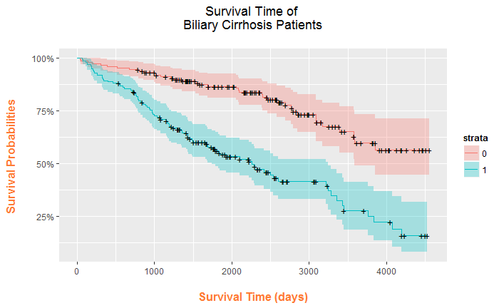

```r
model_fit_hepato <- survfit(Surv(pbc$time, pbc$status == 2) ~ pbc$hepato)
autoplot(model_fit_hepato) +
    labs(x = "\n Survival Time (days) ", y = "Survival Probabilities \n",
    title = "Survival Time of \n Biliary Cirrhosis Patients \n") +
    theme(plot.title = element_text(hjust=0.5),
    axis.title.x = element_text(face = "bold", color = "#FF7A33", size = 12),
    axis.title.y = element_text(face = "bold", color = "#FF7A33", size = 12),
    legend.title = element_text(face = "bold", size = 10))
```

```r
survdiff(Surv(pbc$time, pbc$status==2)~pbc$hepato)
```

```
Call:
survdiff(formula = Surv(pbc$time, pbc$status == 2) ~ pbc$hepato)

n=312, 106 observations deleted due to missingness.

               N Observed Expected (O-E)^2/E (O-E)^2/V
pbc$hepato=0 152       37     71.7      16.8      40.2
pbc$hepato=1 160       88     53.3      22.6      40.2

 Chisq= 40.2  on 1 degrees of freedom, p= 2.31e-10
```

#### Using Survminer package, simple curve:

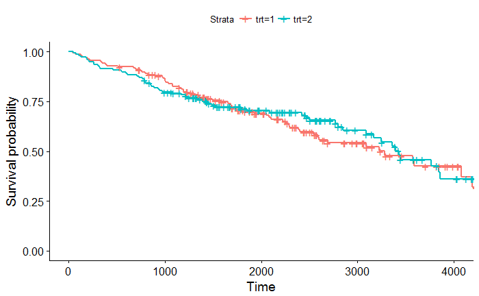

```r
ggsurvplot(model_fit_trt, data = pbc)
```

#### Curve containing risk table:

[figure not shown]

```r
ggsurv <- ggsurvplot(model_fit_trt, data = pbc, title = "Survival Time of \n Biliary Cirrhosis Patients \n",
legend.title = "Treatment",
legend.labs = c("One", "Two"),
xlab = "\n Survival Time (days) ",
ylab = "Survival Probabilities \n",
risk.table = TRUE,
risk.table.title = "Risk Table",
conf.int = TRUE)
ggsurv
```

## 2.2 Cox Proportional Hazard

### Formal Background

Cox PH gives us the hazard rates of all subjects under observation. Hazard rate = parametric part * non parametric part. The parametric part captures the relative hazard inferred by the covariates and is not dependent on time. The non parametric part is defined by the ratio of event / no event and is independent of the covariates.

The effect of covariates can be estimated independent of the baseline hazard by Cox proportional likelihood

See blackboard for formula!

### Preparation

#### Train and test data sets for PDC set

```r
pbc_clean <- pbc[!is.na(pbc$age)
                 & !is.na(pbc$edema)
                 & !is.na(pbc$bili)
                 & !is.na(pbc$albumin)
                 & !is.na(pbc$protime)
                 ,]
#Selecting 75%  from initial population
samplepbc <- sample.int(n = NROW(pbc_clean), size = floor(.75*NROW(pbc_clean)), replace = F)
trainpbc <- pbc_clean[samplepbc,]
testpbc  <- pbc_clean[-samplepbc,]
```

#### Train and test data sets for HDD set

```r
trainsn <- unique(cox_data[cox_data$startdate ==0,]$serial_number)
trainsn <- trainsn[sample(NROW(trainsn))] # shuffle
#Selecting 75% of serial numbers from initial population
sample <- sample.int(n = NROW(trainsn), size = floor(.75*NROW(trainsn)), replace = F)
train <- trainsn[sample ]
test  <- trainsn[-sample ]
trainset <- cox_data[cox_data$serial_number %in% train,]
testset <- cox_data[cox_data$serial_number %in% test,]
```

### Application and code

#### Cox PH on PBC Dataset

building the cox model

```r
pbc.cox <- coxph(Surv(time,status ==2 ) ~age + edema +log(bili) +log(albumin)+log(protime), data = trainpbc)
print(summary(pbc.cox))
```

```
Call:
coxph(formula = Surv(time, status == 2) ~ age + edema + log(bili) +
    log(albumin) + log(protime), data = trainpbc)

  n= 312, number of events= 115

                  coef exp(coef)  se(coef)      z Pr(>|z|)
age           0.036143  1.036804  0.008917  4.053 5.05e-05 ***
edema         0.956978  2.603816  0.325544  2.940 0.003286 **
log(bili)     0.852197  2.344792  0.093842  9.081  < 2e-16 ***
log(albumin) -2.827848  0.059140  0.827164 -3.419 0.000629 ***
log(protime)  2.228135  9.282533  0.849775  2.622 0.008741 **
---
Signif. codes:  0 ‘***’ 0.001 ‘**’ 0.01 ‘*’ 0.05 ‘.’ 0.1 ‘ ’ 1

             exp(coef) exp(-coef) lower .95 upper .95
age            1.03680     0.9645   1.01884    1.0551
edema          2.60382     0.3841   1.37565    4.9285
log(bili)      2.34479     0.4265   1.95086    2.8183
log(albumin)   0.05914    16.9090   0.01169    0.2992
log(protime)   9.28253     0.1077   1.75524   49.0903

Concordance= 0.84  (se = 0.03 )
Rsquare= 0.414   (max possible= 0.977 )
Likelihood ratio test= 166.5  on 5 df,   p=0
Wald test            = 169.9  on 5 df,   p=0
Score (logrank) test = 223  on 5 df,   p=0
```

##### Predicting hazard ratios on testset

relative to the sample average for all predictor variables -> these are the betas

```r
coxpredicted_trainpbc <- predict(pbc.cox,type="lp")
coxpredicted_testpbc <- predict(pbc.cox, newdata=testpbc,type="lp")
print(head(coxpredicted_testpbc,10))
```

```
         1          2          6          7         11         21         22         26         31
 4.0592786 -0.8078974 -0.5306439 -1.0854095 -0.4383576 -0.6623923  0.7202686  0.5368995  0.3512169
        36
-1.3512384
```

##### Hazard for each subject

```r
cox_bazehaz <- basehaz(pbc.cox)
print(head(cox_bazehaz,10))
```

|  | hazard | time |
| --- | --- | --- |
| 1 | 0.001894238 | 41 |
| 2 | 0.002985335 | 51 |
| 3 | 0.004152179 | 71 |
| 4 | 0.005337563 | 77 |
| 5 | 0.006553208 | 94 |
| 6 | 0.007773576 | 130 |
| 7 | 0.009052880 | 131 |
| 8 | 0.010389146 | 179 |
| 9 | 0.011845069 | 186 |
| 10 | 0.013308074 | 191 |

```r
cox_predhaz_t110 <- cox_bazehaz[5,1]*coxpredicted_testpbc
print(head(cox_predhaz_t110, n=10))
```

```
           1            2            6            7           11           21           22           26
 0.026601297 -0.005294320 -0.003477420 -0.007112914 -0.002872649 -0.004340794  0.004720070  0.003518414
          31           36
 0.002301598 -0.008854946
```

##### Calculate Survival probabilities of subjects in testset

```r
Pred_Prob <- predictSurvProb(pbc.cox,newdata=testpbc,times=c(110))
print(head(Pred_Prob, n=10))
```

```
        [,1]
1  0.6841051
2  0.9970829
6  0.9961527
7  0.9977890
11 0.9957815
21 0.9966268
22 0.9866235
26 0.9888521
31 0.9907324
36 0.9983047
```

#### Cox PH on HDD Dataset

##### Building the cox model

```r
train.cox <- coxph(Surv(startdate, date, failure) ~ smart_9_normalized + smart_5_normalized +smart_187_normalized
                   +smart_188_normalized+smart_197_normalized + smart_198_normalized,
                   data = trainset)
print(summary(train.cox))
```

```
Call:
coxph(formula = Surv(startdate, date, failure) ~ smart_9_normalized +
    smart_5_normalized + smart_187_normalized + smart_188_normalized +
    smart_197_normalized + smart_198_normalized, data = trainset)

  n= 79390, number of events= 200

                          coef exp(coef)  se(coef)       z Pr(>|z|)
smart_9_normalized   -0.064957  0.937108  0.006667  -9.743   <2e-16 ***
smart_5_normalized   -0.075612  0.927176  0.006593 -11.468   <2e-16 ***
smart_187_normalized -0.131680  0.876621  0.009582 -13.743   <2e-16 ***
smart_188_normalized  0.352254  1.422270  1.111972   0.317    0.751
smart_197_normalized  0.075672  1.078609  0.007138  10.602   <2e-16 ***
smart_198_normalized -0.013561  0.986531  0.011150  -1.216    0.224
---
Signif. codes:  0 ‘***’ 0.001 ‘**’ 0.01 ‘*’ 0.05 ‘.’ 0.1 ‘ ’ 1

                     exp(coef) exp(-coef) lower .95 upper .95
smart_9_normalized      0.9371     1.0671    0.9249    0.9494
smart_5_normalized      0.9272     1.0785    0.9153    0.9392
smart_187_normalized    0.8766     1.1407    0.8603    0.8932
smart_188_normalized    1.4223     0.7031    0.1609   12.5746
smart_197_normalized    1.0786     0.9271    1.0636    1.0938
smart_198_normalized    0.9865     1.0137    0.9652    1.0083

Concordance= 0.76  (se = 0.02 )
Rsquare= 0.003   (max possible= 0.047 )
Likelihood ratio test= 199.7  on 6 df,   p=0
Wald test            = 396.7  on 6 df,   p=0
Score (logrank) test = 2066  on 6 df,   p=0
```

##### Predicting hazard ratios on testset

```r
coxpredicted_train <- predict(train.cox,type="lp")
coxpredicted_test <- predict(train.cox, newdata=testset,type="lp")
#print(head(coxpredicted_test,10))
```

## 2.2 Accelarated Time To Failure Model

### 2.2.1 Preparation

### 2.2.2 Building the ATF Model

```r
atf_model_weibull <- survreg(Surv(pbc$time, pbc$status == 2) ~ pbc$age + pbc$edema + log(pbc$bili) + log(pbc$albumin) + log(pbc$protime), dist='weibull')
```

```
Ran out of iterations and did not converge
```

```r
summary(atf_model_weibull)
```

```
Call:
survreg(formula = Surv(pbc$time, pbc$status == 2) ~ pbc$age +
    pbc$edema + log(pbc$bili) + log(pbc$albumin) + log(pbc$protime),
    dist = "weibull")
                    Value Std. Error      z         p
(Intercept)       5.50126   1.59e-02  345.5  0.00e+00
pbc$age          -0.00559   4.51e-05 -124.0  0.00e+00
pbc$edema        -0.84731   4.47e-03 -189.6  0.00e+00
log(pbc$bili)    -0.28351   6.79e-04 -417.4  0.00e+00
log(pbc$albumin)  1.57928   5.27e-03  299.5  0.00e+00
log(pbc$protime)  0.19590   6.43e-03   30.5 4.14e-204
Log(scale)       -3.59300   0.00e+00   -Inf  0.00e+00

Scale= 0.0275

Weibull distribution
Loglik(model)= -35586   Loglik(intercept only)= 0
    Chisq= -71171.96 on 5 degrees of freedom, p= 1
Number of Newton-Raphson Iterations: 30
n= 418
```

```r
atf_model_exponential <- survreg(Surv(pbc$time, pbc$status == 2) ~ pbc$age + pbc$edema + log(pbc$bili) + log(pbc$albumin) + log(pbc$protime), dist='exponential')
```

```
Ran out of iterations and did not converge
```

```r
summary(atf_model_exponential)
```

```
Call:
survreg(formula = Surv(pbc$time, pbc$status == 2) ~ pbc$age +
    pbc$edema + log(pbc$bili) + log(pbc$albumin) + log(pbc$protime),
    dist = "exponential")
                    Value Std. Error         z p
(Intercept)      37.42294    5142738  7.28e-06 1
pbc$age          -0.00556      39467 -1.41e-07 1
pbc$edema        -0.82899    1593309 -5.20e-07 1
log(pbc$bili)    -0.28358     423818 -6.69e-07 1
log(pbc$albumin)  1.57848    3392988  4.65e-07 1
log(pbc$protime)  0.19409     940577  2.06e-07 1

Scale fixed at 1

Exponential distribution
Loglik(model)= 0   Loglik(intercept only)= 0
    Chisq= 0 on 5 degrees of freedom, p= 1
Number of Newton-Raphson Iterations: 30
n= 418
```

```r
atf_model_log <- survreg(Surv(pbc$time, pbc$status == 2) ~ pbc$age + pbc$edema + log(pbc$bili) + log(pbc$albumin) + log(pbc$protime), dist='loglogistic')
```

```
Ran out of iterations and did not converge
```

```r
summary(atf_model_log)
```

```
Call:
survreg(formula = Surv(pbc$time, pbc$status == 2) ~ pbc$age +
    pbc$edema + log(pbc$bili) + log(pbc$albumin) + log(pbc$protime),
    dist = "loglogistic")
                    Value Std. Error      z        p
(Intercept)       6.07959     1.7192  3.536 0.000406
pbc$age          -0.00659     0.0246 -0.268 0.788702
pbc$edema        -0.68517     0.7332 -0.935 0.350042
log(pbc$bili)    -0.26100     0.0000   -Inf 0.000000
log(pbc$albumin)  2.27961     0.0000    Inf 0.000000
log(pbc$protime)  0.17486     0.0000    Inf 0.000000
Log(scale)       -6.80668    74.8086 -0.091 0.927502

Scale= 0.00111

Log logistic distribution
Loglik(model)= 0   Loglik(intercept only)= 0
    Chisq= 0 on 5 degrees of freedom, p= 1
Number of Newton-Raphson Iterations: 30
n= 418
```

```r
par(mfrow = c(2, 2))
pred_atf <- prediction(predict(atf_model_weibull), pbc$status)
```

[output not shown]

## 2.3 Survival Gradient Boosting with Cox

### Formal Background

Gradient Boosting comes from the family of ensemble learning techniques. A weak learner, in our case a decision tree, is fitted sequentially to create a stronger predictive model. In general it tries to iteratively map y <- x*beta in such a way that a cost function is minimized. beta is the set of parameters.

See blackboard for formula.

### Application on PBC Set

#### Building the model

#### Predicting hazard ratios on testset

### Application on HDD Set

gbm does not support intervall partitioned data. therefore we look at the full timespan

#### Building the model

#### Predicting hazard ratios on testset

# 3. Benchmark and Prediction

## 3.3 Benchmarking Methods

### 3.3.1 ROC - Receiver operating characteristic

## Generate predictions of cox_model and performance variable and plot the ROC

Sensitivity: Probability that a person with the disease will have a positive test result. Specificity: Probability that a person without the disease will have a negative test result.

At every cutoff, the TPR and FPR are calculated and plotted. The smoother the graph, the more cutoffs the predictions have.

### 3.3.2 AUC - Area under the curve

## 3.4 Benchmark the models

Training a data set

## 3.7 Concordance Index

The output of the cox function are relative hazards. Lower hazard in general means longer survival time and vice versa. Therefore Cox implicitly ranks subjects by hazard (thus by survival time). The goodness of ranking can me measured by CI.

CI is the fraction of correctly ordered pairs of subjects compared to all pairs of subjects that can be ordered (Every pair that includes at least one actual failure)

For formula see blackboard.

### CI for COX PH HDD Set

### Calculating Concordance Index to assess results of prediction

CI Could also be used to learn a GBM Model (GBMCI) Model tries to rank subjects by survival times so that CI becomes optimal

## 4 Evaluation and Future Outlook

It can happen that we have different costs for false negative and false positive The output from opt.cut and a performance object with measure cost are NOT equivalent if false positives and false negatives are not weighted equally. The cost.fn and cost.fp arguments can be passed to performance, corresponding to the cost of a false negative and false positive, respectively (This is minimize cost criterion).

### Plotting the new line

### Address now for evaluation the partial AUC, this value can range from 0 to infinity

### Divide pAUC by fpr.stop to receive a standardized result form 0 to 1 like AUC

### Backup - FOR Concordance Indices